# Tanı Testlerine Giriş ve Tanı Testlerinin Birleştirilmesi

Serra İlayda YERLİTAŞ, MsC.

13 Mayıs 2022

# 1 Tanı Testleri Amaçları

Tıp alanında karar verme, çoğunlukla hekimin bir kişide belirli bir hastalığın olduğu ya da olmadığı şeklinde tanı koyması süreci olarak karşımıza çıkar. Bu süreçte hekim, hastasından aldığı bilgilerin (şikâyetler, belirtiler, fizik muayene bulguları, soy geçmişi vb.) ışığı altında, kendi deneyimleri ile birlikte olası hastalıklar içerisinden birinin ya da birkaçının varlığını kanıtlamak ya da dışlamak gibi seçeneklerle karşı karşıya kalır.

Kesin olmayışlığın ya da belirsizliğin azaltılabilmesi, hatta olanaklı ise ortadan kaldırılabilmesi için ek bilgilere gereksinim duyulur. Bu tür ek bilgiler çoğunlukla tanı - laboratuvar testleri ile sağlanır. Tanı ya da laboratuvar testleri kesinlik, maliyet, hasta için risk oluşturma ve sonuçlanma süresi açısından çok değişkenlik gösterebilmektedir. Bazı testler kesin sonuç vermekle birlikte uygulama zorluğu ya da hastaya yüklediği riskler açısından tercih edilmeyebilir. Belirli bir hastalığın varlığını ya da yokluğunu kesin ya da kesine yakın doğrulukla gösterebilen yüksek maliyetli ve riskli testleri öncelikle herkese uygulamak yerine, önce düşük maliyetli ancak daha az kesin testleri uygulayıp, bunların sonuçlarına göre maliyeti yüksek testi gerçekten gerekli görülen sınırlı sayıda hastaya uygulamak daha uygun olabilir.

Referans test ya da altın standart test olarak da adlandırılan kesin testler, hastalarla hastalığa sahip olmayan kişileri %100 doğrulukla ayırabilirler. Bazı görüntüleme teknikleri, patolojik ve histolojik değerlendirmeler genellikle hatasızdır. Referans testler dışında kalan, başka bir deyişle hastalar ile hastalığa sahip olmayanları %100 doğru ayırt edemeyen testlerin tanı sürecinde kullanılabilmeleri için, ne doğrulukta ayrımsama yapabildiklerinin bilinmesi gerekir. Bunun için tanı testi bir referans testle birlikte aynı grup üzerinde uygulanmalıdır.

En kötü test ve hiç hatasız ayrımsama yapan en mükemmel test arasında kalan tanı testlerinin ayırt edicilik başarısının değerlendirilebilmesi için bazı ölçüler geliştirilmiştir.

# 2 Performanslarının Değerlendirilmesinde Kullanılan Yöntemler:

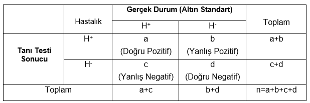

- **Duyarlılık (Sensitivity, True Positive Rate , Recall):** Tanı testinin gerçekte hasta olanlar arasından hastaları ayırt edebilme olasılığıdır.

$$\begin{equation} \label{eqn:formula70}
Duyarlılık = \left(\frac{a}{a + c}\right)
\end{equation}$$

- **Seçicilik (Specificity, True Negative Rate):** Tanı testinin gerçekte sağlıklı olanlar arasından sağlıklıları ayırt edebilme olasılığıdır.

$$\begin{equation} \label{eqn:formula23}
Seçicilik = \left(\frac{d}{b + d}\right)
\end{equation}$$

- **Pozitif Kestirim Değeri (Positive Predictive Value, Precision):** Tanı testinin hasta olarak belirlediklerinin gerçekte hasta olma olasılığıdır.

$$\begin{equation} \label{eqn:formula60}
PKD = \left(\frac{a}{a + b }\right)
\end{equation}$$

- **Negatif Kestirim Değeri (Negative Predictive Value):** Tanı testinin sağlıklı olarak belirlediklerinin gerçekte sağlıklı olma olasılığıdır.

$$\begin{equation} \label{eqn:formula20}
NKD = \left(\frac{d}{c + d}\right)
\end{equation}$$

- **Yanlış Pozitif Oranı (False Positive Rate):** Tanı testinin gerçekte sağlıklı olan kişileri hasta olarak belirleme oranıdır.

$$\begin{equation} \label{eqn:formula21}
YPO = \left(\frac{b}{b + d}\right)
\end{equation}$$

- **Yanlış Negatif Oranı (False Negative Rate):** Tanı testinin gerçekte hasta olan kişileri sağlıklı olarak belirleme oranıdır.

- **Doğruluk Oranı (Accuracy):** Tanı testinin hastaları hasta, sağlıklıları ise sağlıklı olarak belirleme oranıdır.

- **Prevelans** Belirli bir nüfusta, belirli bir zaman dilimi içerisinde, çalışma kapsamında yer alan belirli bir hastalığa sahip olguların oranıdır.

**Örnek:**

Aşağıdaki tanı testinin performans ölçülerini hesaplayınız.

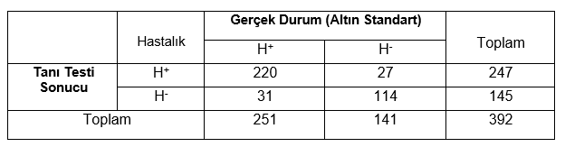

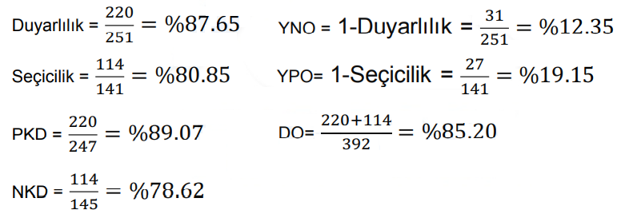

**Örnek 2:**

[figure not shown]

# 3 ROC Analizi

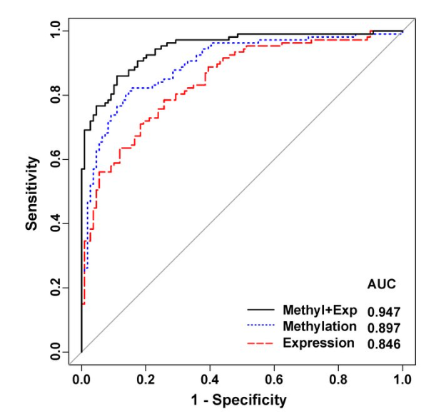

## 3.1 ROC Eğrisinin Özellikleri

1. Bir tanı testinin performansını değerlendirmek için kullanılabilir.
2. Birden fazla tanı testinin performanslarını karşılaştırmak için kullanılabilir.
3. Tanı testleri için en iyi kesim noktasını belirlemek için kullanılabilir.

## 3.2 ROC Eğrisi: Performans Değerlendirilmesi

**Eğri Altında Kalan Alan (Area Under the Curve, AUC)**

- Bir tanı testi sonucunda hastalarla sağlıklıların birbirinden ne kadar iyi ayrıldığı ölçen performans ölçüsüdür.
- 0.5 < AUC < 1
- 0.5 değeri testin hastaları ayırt etmede hiç bir bilgi sağlamadığını, 1.0 değeri ise bütün hastaların ve sağlıklıların doğru sınıflandığını gösterir (Altın test).

## 3.3 ROC Eğrisi: En Uygun Kesim Noktasının Bulunması

**Örnek 3:**

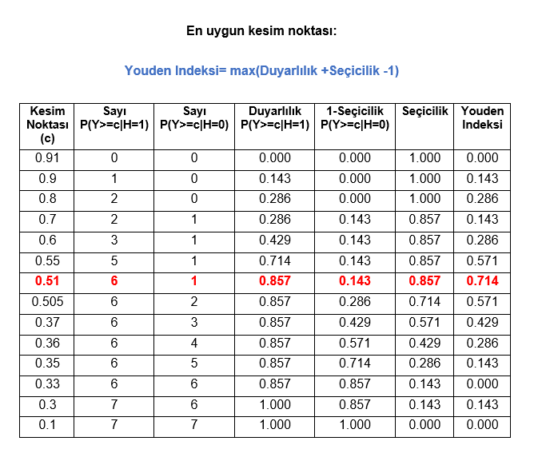

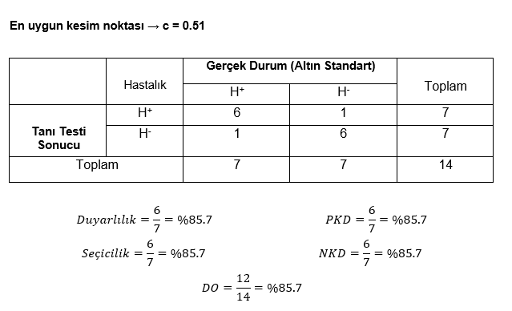

**Tanı testleri için elde edilen performans ölçülerinden amaca yönelik olarak seçilenleri en uygun kesim noktasının belirlenmesi için kullanılabilir. En uygun kesim noktasının belirlenmesinde dikkate alınacak kriterler şunlar olabilir:**

1. Seçiciliği yüksek olan bir test.
2. Duyarlılığı yüksek olan bir test.
3. Genel başarısı yüksek olan bir test(En uygun düzeyde duyarlı ve seçici).

**Seçiciliği yüksek test (Yanlış Pozitif oranı düşük):**

1. Hastalığın varlığı kanıtlanmak istendiğinde,
2. Hastalık tanısı koymanın kişiyi sarsacağı durumlarda,
3. Birinci tip hatadan kaçınılmak istendiğinde,
4. Hastalığın hayati öneminin düşük olduğu durumlarda,
5. Erken tanının önem arz etmediği hastalıklarda,
6. Kesin tanı için kullanılan testler maliyetli olduğunda,
7. … tercih edilebilir.

**Duyarlılığı yüksek test (Yanlış Negatif oranı düşük):**

1. Hastalığın hayati öneme sahip olduğu durumda,
2. Salgın hastalık belirlenmek istendiğinde,
3. İkinci tip hatadan kaçınmak istendiğinde tercih edilebilir.

# 4 R ile ROC Analizi

Öncelikle ROC analizini uygulayacağımız veri seti için **APtools** paketinin kurulu olması gerekmektedir. Paket içerisinde mevcut olan mayo datası ile bir ROC analizi yapacağız.

```r
library(APtools)

data(mayo)
head(mayo)
```

```
##   time censor mayoscore5 mayoscore4
## 1   41      1  11.251850  10.629450
## 2  179      1  10.136070  10.185220
## 3  334      1  10.095740   9.422995
## 4  400      1  10.189150   9.567799
## 5  130      1   9.770148   9.039419
## 6  223      1   9.226429   9.033388
```

Mayo datası 4 değişkenli olup zaman, sansör, mayoscore5 ve mayoscore4 değişkenlerinden oluşmaktadır. ROC analizinde kullanacağımız referans test bu veri setinde **censor** değişkeni kullanacağımız tanı testleri ise **mayoscore5** ve **mayoscore4** değişkenleridir. ROC analizini uygulamak için **pROC** kütüphanesine ihtiyacamız bulunmaktadır.

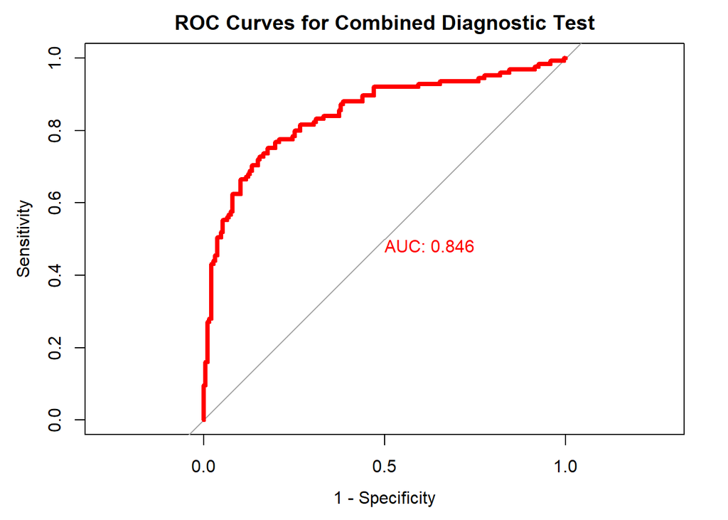

```r
library(pROC)

# mayoscore5 tanı testi için ROC analizi
roc.m5 <- roc(mayo$censor ~ mayo$mayoscore5, plot = TRUE, print.auc = TRUE,
                      direction = "<", col = "red", lwd = 4, legacy.axes = TRUE,
                      percent = FALSE, main = "ROC Curves for Combined Diagnostic Test")
```

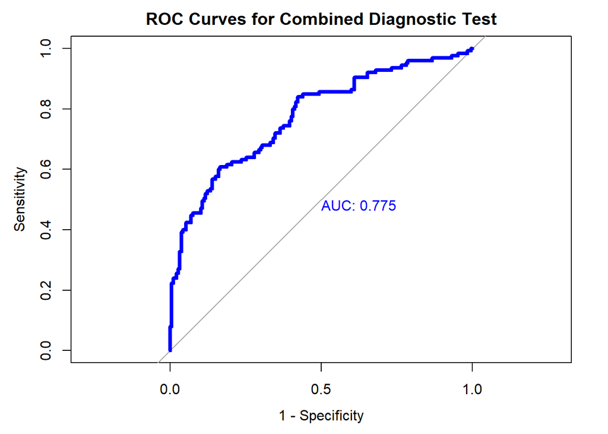

```r
# mayoscore4 tanı testi için ROC analizi
roc.m4 <- roc(mayo$censor ~ mayo$mayoscore4, plot = TRUE, print.auc = TRUE,
                      direction = "<", col = "blue", lwd = 4, legacy.axes = TRUE,
                      percent = FALSE, main = "ROC Curves for Combined Diagnostic Test")
```

Kesim değeri ve diğer performans ölçülerini belirlemek için öncelikle ROC analizi koordinatlarına daha sonra confusion matrisine ihtiyacımız bulunmaktadır. Karmaşıklık matrisi (confusion matrix) veya 2×2 tablo oluşturabilmek için **epiR** kütüphanesinin kurulu olması gerekmektedir.

```r
library(epiR)

#Roc koordinatları

coord.m5 <- coords(roc.m5)
coord.m4 <- coords(roc.m4)

# Karmaşıklık matrisi (confusion matrix) veya 2×2 tablo
best.m5 <- coords(roc.m5, "best", ret = c("threshold","tp","tn","fp","fn"),
                          best.method = "youden")
best.m4 <- coords(roc.m4, "best", ret = c("threshold","tp","tn","fp","fn"),
                          best.method = "youden")

best.m5.tbl <- as.table(matrix(c(best.m5$tp, best.m5$fp, best.m5$fn, best.m5$tn),
                                 nrow = 2, byrow = TRUE))
best.m4.tbl <- as.table(matrix(c(best.m4$tp, best.m4$fp, best.m4$fn, best.m4$tn),
                                 nrow = 2, byrow = TRUE))

# Performans Degerlendirmesi
DiagStatMayoscore5 <- epi.tests(best.m5.tbl, conf.level = 0.95)
DiagStatMayoscore5
```

```
##           Outcome +    Outcome -      Total
## Test +           94           33        127
## Test -           31          154        185
## Total           125          187        312
##
## Point estimates and 95% CIs:
## --------------------------------------------------------------
## Apparent prevalence *                  0.41 (0.35, 0.46)
## True prevalence *                      0.40 (0.35, 0.46)
## Sensitivity *                          0.75 (0.67, 0.82)
## Specificity *                          0.82 (0.76, 0.88)
## Positive predictive value *            0.74 (0.65, 0.81)
## Negative predictive value *            0.83 (0.77, 0.88)
## Positive likelihood ratio              4.26 (3.08, 5.90)
## Negative likelihood ratio              0.30 (0.22, 0.41)
## False T+ proportion for true D- *      0.18 (0.12, 0.24)
## False T- proportion for true D+ *      0.25 (0.18, 0.33)
## False T+ proportion for T+ *           0.26 (0.19, 0.35)
## False T- proportion for T- *           0.17 (0.12, 0.23)
## Correctly classified proportion *      0.79 (0.75, 0.84)
## --------------------------------------------------------------
## * Exact CIs
```

```r
DiagStatMayoscore4 <- epi.tests(best.m4.tbl, conf.level = 0.95)
DiagStatMayoscore4
```

```
##           Outcome +    Outcome -      Total
## Test +           76           31        107
## Test -           49          156        205
## Total           125          187        312
##
## Point estimates and 95% CIs:
## --------------------------------------------------------------
## Apparent prevalence *                  0.34 (0.29, 0.40)
## True prevalence *                      0.40 (0.35, 0.46)
## Sensitivity *                          0.61 (0.52, 0.69)
## Specificity *                          0.83 (0.77, 0.88)
## Positive predictive value *            0.71 (0.61, 0.79)
## Negative predictive value *            0.76 (0.70, 0.82)
## Positive likelihood ratio              3.67 (2.58, 5.21)
## Negative likelihood ratio              0.47 (0.37, 0.59)
## False T+ proportion for true D- *      0.17 (0.12, 0.23)
## False T- proportion for true D+ *      0.39 (0.31, 0.48)
## False T+ proportion for T+ *           0.29 (0.21, 0.39)
## False T- proportion for T- *           0.24 (0.18, 0.30)
## Correctly classified proportion *      0.74 (0.69, 0.79)
## --------------------------------------------------------------
## * Exact CIs
```

# 5 Tanı Testlerinin Birleştirilmesi (dtComb Paketi)

Tanı testlerinin istatistiksel yöntemler kullanılarak birleştirilmesi ile bazı çalışmalarda da gösterildiği gibi, üstün performansa sahip yeni tanı test performans ölçümleri elde edilebilmektedir. Tanı testlerinin performans artırmaya ve birleştirilmesine yönelik literatürde çok sayıda yöntem bulunsa da, bu yöntemlerin uygulanabileceği kapsamlı bir yazılım bulunmamaktadır. İki tanı testinin birleştirilmesine yönelik geliştirilmiş ve dağınık biçimde yer alan çok sayıda yöntemi dtComb R kütüphanesi altında bir araya getirdik. dtComb paketi sayesinde kullanıcılar rahatlıkla iki tanı testini birleştirebilir ve yeni veriler için sınıflandırma yapabilir.

```r
library(dtComb)
```

## 5.1 Veri Yükleme

dtComb paketi hastalığın kesinliğinde kullanılan referans test iki kategorili (negatif/pozitif, var/yok), tanı testleri ise sürekli (*continuous*) nicel yapıda olacak şekilde bir data.frame bekler.

`data` fonksiyonunu kullanarak veriyi çağırabiliriz.

```r
# load exampleData1
data(exampleData1)
```

Sınıflandırma modellerini eğitmek için kullanılacak 169 örneğimiz ve model performanslarını test etmek için kullanılacak 56 örneğimizi oluşturuyoruz. Eğitim ve test setleri:

```r
# # train set of the exampleData1
trainData <- exampleData1[-c(83:138),]
testData <- exampleData1[c(83:138), 2:3]
head(trainData)
```

```
##    group ddimer log_leukocyte
## 1 needed   8.09          5.52
## 2 needed   5.16          4.43
## 3 needed   8.90          5.20
## 4 needed  10.17          5.39
## 5 needed   1.93          5.09
## 6 needed   3.63          4.68
```

Group sütununda 169 gözlemden 82 gözlem laparotomi gerektirirken 87, gözlem laparotomi gerektirmemektedir.

```r
## Değişkenlerin oluşturulması
markers <- trainData[, -1]
status <- factor(trainData$group, levels = c("not_needed", "needed"))
```

## 5.2 Mevcut Yöntemler

Tanı testlerini birleştirmek için oldukça fazla sayıda yöntem vardır. Bu yöntemlerden en basiti iki tanı testini oranlamaktır. dtComb paketinde tanı testlerini birleştirmeye yönelik 143 adet yöntem bulunmaktadır. Bu yöntemler doğrusal yöntemler, doğrusal olmayan yöntemler, matematiksel operatörler ve makine öğrenmesi algoritmaları olarak dört gruba ayrılmıştır.

### 5.2.1 Doğrusal Kombinasyon Metotları:

- **Lojistik Regresyon tabanlı Skorlama (scoring):** İlgili lojistik regresyon modelinin tahmin edilen beta/regresyon katsayılarını kullanılarak kombinasyon puanı elde edilmekte, tahmin edilen beta/regresyon katsayıları kullanıcıdan alınan basamak sayısına yuvarlanmaktadır.

$$\begin{equation} \label{eqn:formula1}
l = \log_b\left(\frac{p}{1 - p}\right) = \beta_0 + \beta_1 x_1 +
\beta_2 x_2
\\
Combination\; Score = \beta_1 x_1 + \beta_2 x_2
\end{equation}$$

- **Su ve Liu’nun yöntemi (SL):** Su ve Liu’nun kombinasyon skoru, çok değişkenli normal dağılım modeli ve orantılı kovaryans matrisleri varsayımı altında Fisher’in diskriminant fonksiyonunu kullanılarak elde edilmektedir [2].

$$\begin{equation} \label{eqn:formula2}
Contol\; group = X \sim N(\mu_x , \sum)
\\
Disease \: group = Y \sim N(\mu_y ,\sigma ^ 2 \sum)
\\
Fisher's\; discriminant \;coefficient = (\alpha , \beta) \propto
(\mu_y- \mu_x) ^ T{\sum_{}^{\;\;\;\;\;\;\;\;-1}}
\\
Combination \;Score = \alpha x_1 + \beta x_2
\end{equation}$$

- **Lojistik Regresyon (logistic):** Lojistik regresyon modelinin kurulmasıyla elde edilen kombinasyon skorudur.

$$\begin{equation} \label{eqn:formula3}
l = \log_b\left(\frac{p}{1 - p}\right) = \beta_0 + \beta_1 x_1 +
\beta_2 x_2
\end{equation}$$

- **Min-Max yöntemi (minmax):** İlgili Mann-Whitney istatistiğini maksimize eden bir parametre olan $\lambda$ ’yı bularak biyobelirteçlerin minimum ve maksimum değerlerini doğrusal olarak birleştirilmektedir [3].

$$\begin{equation} \label{eqn:formula13}
Control \; group: X_i = (X_1i, X_2i), i = 1, 2, ..., n
\\
Disease \; group : Y_j = (Y_1j, Y_2j), j = 1, 2, ..., m
\\
maximize\;W( \lambda ) = \left(\frac{1}{mn}\right) {\sum_{i=1}^{n}
{\sum_{j=1}^{m}}I(Y_{j,max} + \lambda Y_{j,min} > X_{i,max}
+ \lambda X_{i,min})}
\\
Combination \; Score = x_{max} + \lambda x_{min}
\end{equation}$$

- **Pepe ve Thompson’ın yöntemi (PT):** İlgili lojistik regresyon modelinin tahmin edilen beta/regresyon katsayılarının oranlanmasıyla elde edilen $\lambda$ parametresi yardımıyla kombinasyon skoru elde edilmektedir [4].

$$\begin{equation} \label{eqn:formula14}
l = \log_b\left(\frac{p}{1 - p}\right) = \beta_0 + \beta_1 x_1 +
\beta_2 x_2
\\
\lambda = \beta_2/\beta_1
\\
Combination \; Score = x_1 + \lambda x_2
\end{equation}$$

- **Pepe, Cai ve Langton’ın yöntemi (PCL):** Lojistik regresyon modelinin parametresi olarak AUC kullanılarak elde edilen kombinasyon skorudur [5].

$$\begin{equation} \label{eqn:formula15}
Control \; group: X_i = (X_1i, X_2i), i = 1, 2, ..., n
\\
Disease \; group = Y_j = (Y_1j, Y_2j), j = 1, 2, ..., m
\\
maximize\; W(\lambda) = \left(\frac{1}{mn}\right) {\sum_{i=1}^{n}
{\sum_{j=1}^{m}}I(Y_{1j} + \lambda Y_{2j} > X_{1i} + \lambda X_{2i})
+ \left(\frac{1}{2} \right) I(Y_{1j} + \lambda Y_{2j} = X_{1i} + \lambda
X_{2i})}
\\
Combination \; Score = x_1 + \lambda x_2
\end{equation}$$

- **Minimax yaklaşımı (minimax):** Kombinasyon skoru Minimax prosedürü ile elde edilir. t parametresi, kombinasyon skorunda maksimum AUC’yi veren değer olarak seçilmektedir [6].

$$\begin{equation} \label{eqn:formula16}
Contol \;group: X_i = (X_{1i}, X_{2i}), i = 1, 2, ... , n
\\
Disease \; group = Y_j = (Y_{1j}, Y_{2j}), j = 1, 2, ... , m
\\
(b_1, b_2) = {[t {\sum_{\;\;\;\;\;\;\;D}} + (1 - t)
\sum_{\;\;\;\;\;\;\;C}] ^ {-1}}{(\mu_D - \mu_C)}
\\
Combination\; Score = b_1 x_1 + b_2 x_2
\end{equation}$$

- **Todor ve Saplacan’ın yöntemi (TS):** Karşılık gelen AUC’yi optimize eden $\Theta$ değerinin trigonometrik fonksiyonları kullanmasıyla elde edilen kombinasyon skorudur [7].

$$\begin{equation} \label{eqn:formula17}
Combination \: Score = sin(\theta)x_1 + cos(\theta)x_2
\end{equation}$$

### 5.2.2 Doğrusal Olmayan Kombinasyon Metotları:

- **Polinomsal Regresyon(polyreg):** Yöntem, oluşturulan polinom özellik uzayıyla bir lojistik regresyon modeli kurmakta ve her gözlem için pozitif olayın olasılığını vermektedir.
- **Polinomsal Ridge Regresyon(ridgereg):** Yüksek korelasyonlu değişkenlerin katsayılarını ve bu durumda iki tanı testinden oluşturulan polinom değişken uzayını tahmin etmek için kullanılan bir cezalandırılmış regresyon yöntemidir. Yöntemin uygulanması için, “glmnet” kütüphanesi kullanılmıştır [8].
- **Polinomsal Lasso Regresyon(lassoreg):** Lasso regresyon cezalandırılmış bir regresyon yöntemidir, bu yöntemin farkı ise sonunda bazı değişkenlerin katsayılarını 0 olarak belirlemesi, bu yöntemi değişken eleme için de kullanışlı kılmaktadır. Uygulama Ridge regresyonuna benzer, parametre seçimi ve model uyumu için çapraz doğrulama “glmnet” kütüphanesi ile uygulanır [8].
- **Polinomsal Elastik Net Regresyon(elasticreg):** Ridge ve Lasso regresyon cezalarının birleştirilmesiyle Elastik Net regresyon elde edilmektedir. Model yine, Ridge ve Lasso regresyonlarının ceza fonksiyonlarının ağırlıklarını belirlemek için 0 (Ridge) ile 1 (Lasso) arasında bir değer alan bir karıştırma parametresi $\alpha$ içermektedir.
- **Splines:** Parçalı fonksiyonların kullanımı ile veri seti üzerinde birden fazla polinomsal lojistik regresyon modeli oluşturulmasını sağlayan matematiksel yaklaşımdır. Uygulanması için “splines” kütüphanesi kullanılmıştır [9].
- **Smoothing Spline ve Doğal Kübik Spline(sgam ve nsgam):** Spline yapısına ek olarak, R’deki “gam” kütüphanesi kullanılarak doğal kübik spline ve smoothing spline’ları ile uygulanır [10].

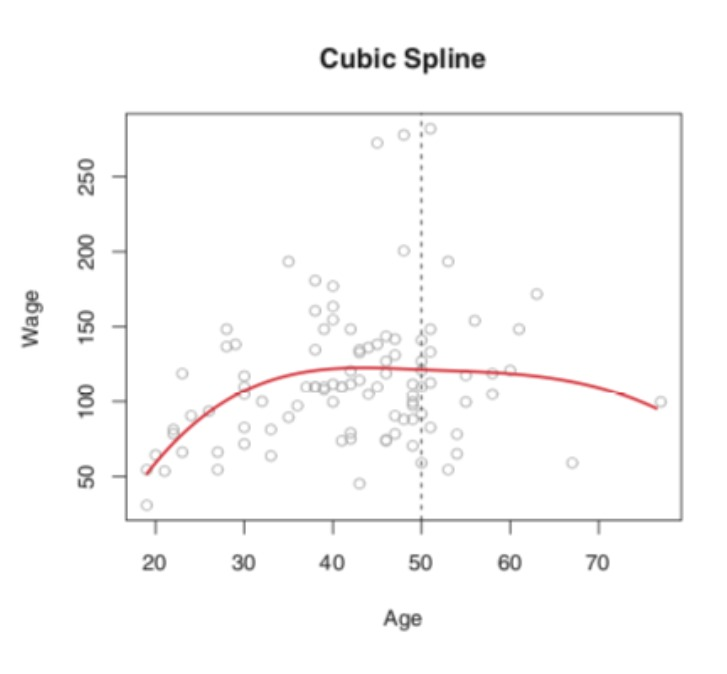

### 5.2.3 Matematiksel Operatörler

Hangi metotlar var?

- **add**
- **subtract**
- **multiply**
- **divide**
- **distance (Euclidean, Manhattan, Chebyshev, Kulczynskid, Lorentzian, Avg, Taneja, Kumar-Johnson)**
- **baseinexp (x üzeri y)**
- **expinbase (y üzeri x)**

Veri setine dönüşüm uygulayabiliriz.

- **log**
- **exp**
- **sin**
- **cos**

### 5.2.4 Makine Öğrenmesi Algoritmaları

Makine öğrenmesi modellerini eğitmek ve bu modellere tahmin yapmak için kullanılan Caret kütüphanesi içerisinde mevcut olan 113 makine öğrenmesi algoritması `mlComb` fonksiyonu kapsamında kullanılmaktadır. [11]

Makine öğrenmesi algoritmalarını görmek için (model training):

```r
availableMethods()
```

## 5.3 Standartlaştırma

Standartlaştırma veri analizinde önemli adımlardan biridir. Birimleri farklı olan tanı testleri ile ilgilidir. Çoğu durumda verilerin aynı birimde olması daha iyi sonuç verir. Standartlaştırma dtComb paketinde mevcut olan bazı kombinasyon yöntemlerinde varsayılan olarak standartlaştırma gerektirse de, tüm modeller için uygulanabilecek bir seçenek olarak verilmiştir. `linComb`, `nonlinComb` ve `mathComb` fonksiyonları için diğer kütüphanelere bağlı kalmadan standartlaştırma metodları hazırlanmış olup standartlaştırma için kullanılan yöntemlerin detayları aşağıda verilmiştir:

- **range:** 0 ile 1 aralığında standartlaştırma
- **zScore:** Ortalama 0’a ve standart sapma 1’e eşit olan z puanları kullanılarak standartlaştırma
- **tScore:** t puanlarını kullanarak standartlaştırma. Aralık genellikle 20 ile 80 arasında değişir
- **mean:** örneklem ortalamasının 1’e eşit olduğu standartlaştırma
- **deviance:** örneklem standart sapmasının 1’e eşit olduğu standartlaştırma

**Ön işleme (Preprocessing):**

- BoxCox
- YeoJohnson
- expoTrans
- center
- scale
- range
- knnImpute
- bagImpute
- BoxCox
- medianImpute
- pca
- ica
- spatialSign
- corr
- zv
- nzv
- conditionalX

## 5.4 Yeniden örnekleme

Doğrusal ve doğrusal olmayan kombinasyonlarda parametre seçimi için yeniden örnekleme seçenekleri, ilgili fonksiyonlarda uygulanmaktadır. Çapraz Doğrulama (cv), Tekrarlı Çapraz Doğrulama (repeatedcv) ve Yeniden Örnekleme (boot) yöntemleri, nfolds, nrepeat ve niters ile birlikte kullanılmak üzere yeniden örnekleme seçenekleri olarak verilmiştir.

**Yeniden Örnekleme (resampling):**

- boot
- boot632
- optimismboot
- bootall
- cv
- repeatedcv
- LOOCV
- LGOCV
- none
- oob
- adaptivecv
- adaptiveboot
- adaptiveLGOCV

## 5.5 Model Kurma

**dtComb** model kurmak ve değerlendirmek için 4 farklı (`linComb`, `nonlinComb`, `mlComb`, `mathComb`) fonksiyona sahiptir. Bu fonksiyonlar kullanıcının seçtiği yöntemler doğrultusunda uygun modeli kurar ve performansları kullanıcıya sunar.

- Doğrusal kombinasyon metotlarında *scoring* yöntemini (*ndgits = 2*) *cv* yeniden örnekleme yöntemi (*nfold = 5*) ile *range* standartlaştırma yöntemlerini kullanarak,
- Doğrusal olmayan kombinasyon metotlarında *lassoreg* yöntemini (*include.interact = “TRUE”*) *boot* yeniden örnekleme yöntemi (*niters= 10*) ile,
- Makine algoritması kombinasyon metotlarında *knn* yöntemini *repeatedcv* yeniden örnekleme yöntemi (*nfolds = 10, nrepeats = 5,*) ile,
- Matematiksel operatörlerden *distance* **(distance = “euclidean”)** yöntemini kullanarak uygulayalım.

```r
set.seed(2128)

#linComb fonksiyonu
lin_result <- linComb(markers = markers,
                      status = status,
                      event = "needed",
                      method = "scoring",
                      resample = "cv",
                      standardize = "range",
                      ndigits = 2, direction = "auto",
                      cutoff.method = "youden")
```

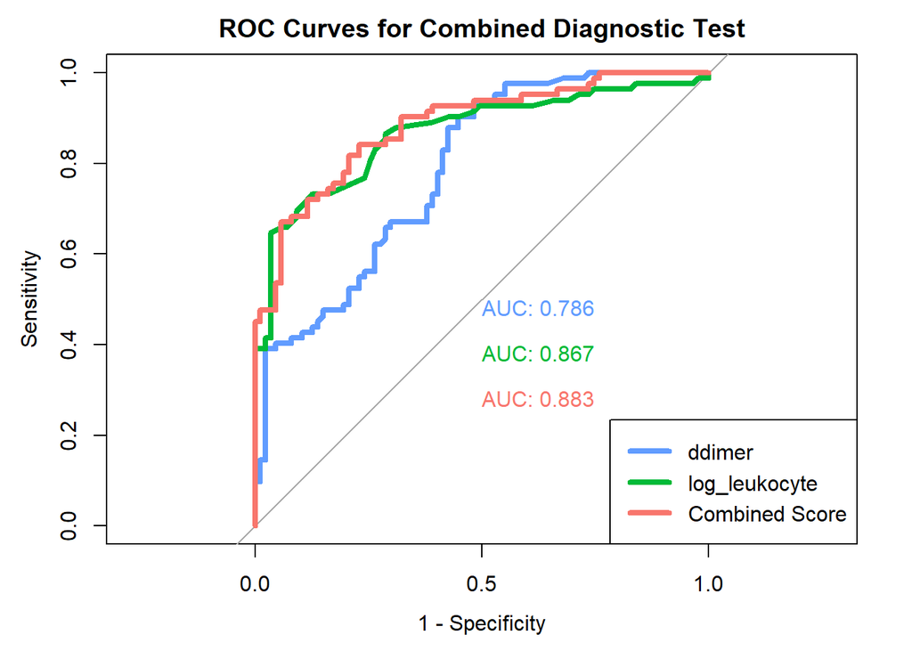

```
## Method: scoring
## Samples: 169
## Markers: 2
## Events: not_needed, needed
## Standardization: range
## Resampling: cv (nfolds: 5)
##  Kappa       Accuracy
##  0.6180251   0.8106509
##
## Area Under the Curves of markers and combined score:
##                     AUC     SE.AUC LowerLimit UpperLimit        z      p.value
## ddimer        0.7858845 0.03416018  0.7189318  0.8528372  8.36894 5.813887e-17
## log_leukocyte 0.8668349 0.02882818  0.8103327  0.9233371 12.72487 4.301880e-37
## Combined      0.8832352 0.02541024  0.8334321  0.9330384 15.08192 2.129828e-51
##
## Area Under the Curve comparison of markers and combined score:
##   Marker1 (A)   Marker2 (B)   AUC (A)   AUC (B)      |A-B|   SE(|A-B|)
## 1    Combined        ddimer 0.8832352 0.7858845 0.09735071  0.03002340
## 2    Combined log_leukocyte 0.8832352 0.8668349 0.01640034  0.01307960
## 3      ddimer log_leukocyte 0.7858845 0.8668349 0.08095038 -0.03971128
##           z     p-value
## 1  3.242494 0.001184883
## 2  1.253886 0.209883330
## 3 -2.038473 0.041502637
##
## Confusion matrix:
##           Outcome +    Outcome -      Total
## Test +           55            5         60
## Test -           27           82        109
## Total            82           87        169
##
## Point estimates and 95% CIs:
## --------------------------------------------------------------
## Apparent prevalence *                  0.36 (0.28, 0.43)
## True prevalence *                      0.49 (0.41, 0.56)
## Sensitivity *                          0.67 (0.56, 0.77)
## Specificity *                          0.94 (0.87, 0.98)
## Positive predictive value *            0.92 (0.82, 0.97)
## Negative predictive value *            0.75 (0.66, 0.83)
## Positive likelihood ratio              11.67 (4.92, 27.70)
## Negative likelihood ratio              0.35 (0.26, 0.48)
## False T+ proportion for true D- *      0.06 (0.02, 0.13)
## False T- proportion for true D+ *      0.33 (0.23, 0.44)
## False T+ proportion for T+ *           0.08 (0.03, 0.18)
## False T- proportion for T- *           0.25 (0.17, 0.34)
## Correctly classified proportion *      0.81 (0.74, 0.87)
## --------------------------------------------------------------
## * Exact CIs
```

```r
#nonlinComb fonksiyonu
nonlin_result <- nonlinComb(markers = markers,
                            status = status,
                            event = "needed",
                            method = "lassoreg",
                            include.interact = "TRUE",
                            resample = "boot",
                            direction = "auto",
                            cutoff.method = "youden")
```

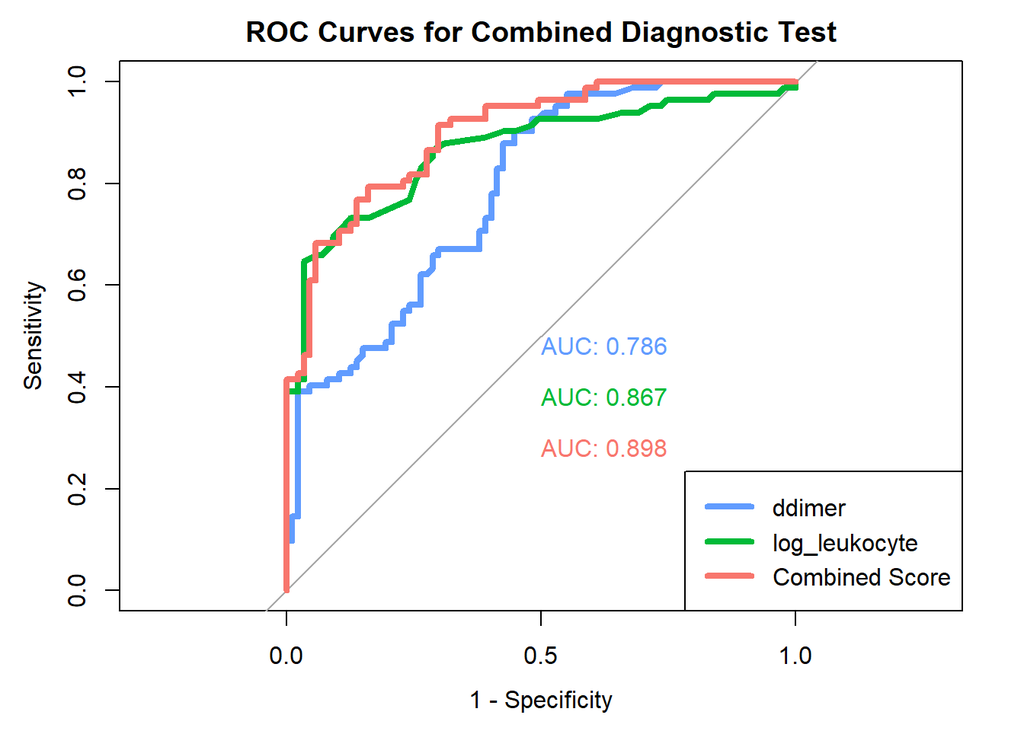

```
## Method: lassoreg
## Samples: 169
## Markers: 2
## Events: not_needed, needed
## Standardization: none
## Resampling: boot (niters: 10)
##  Kappa       Accuracy
##  0.6324283   0.816568
##
## Area Under the Curves of markers and combined score:
##                     AUC     SE.AUC LowerLimit UpperLimit        z      p.value
## ddimer        0.7858845 0.03416018  0.7189318  0.8528372  8.36894 5.813887e-17
## log_leukocyte 0.8668349 0.02882818  0.8103327  0.9233371 12.72487 4.301880e-37
## Combined      0.8978133 0.02280862  0.8531092  0.9425174 17.44136 4.004473e-68
##
## Area Under the Curve comparison of markers and combined score:
##   Marker1 (A)   Marker2 (B)   AUC (A)   AUC (B)      |A-B|   SE(|A-B|)
## 1    Combined        ddimer 0.8978133 0.7858845 0.11192879  0.02979624
## 2    Combined log_leukocyte 0.8978133 0.8668349 0.03097841  0.01475551
## 3      ddimer log_leukocyte 0.7858845 0.8668349 0.08095038 -0.03971128
##           z      p-value
## 1  3.756474 0.0001723244
## 2  2.099447 0.0357775013
## 3 -2.038473 0.0415026367
##
## Confusion matrix:
##           Outcome +    Outcome -      Total
## Test +           65           14         79
## Test -           17           73         90
## Total            82           87        169
##
## Point estimates and 95% CIs:
## --------------------------------------------------------------
## Apparent prevalence *                  0.47 (0.39, 0.55)
## True prevalence *                      0.49 (0.41, 0.56)
## Sensitivity *                          0.79 (0.69, 0.87)
## Specificity *                          0.84 (0.74, 0.91)
## Positive predictive value *            0.82 (0.72, 0.90)
## Negative predictive value *            0.81 (0.71, 0.89)
## Positive likelihood ratio              4.93 (3.01, 8.06)
## Negative likelihood ratio              0.25 (0.16, 0.38)
## False T+ proportion for true D- *      0.16 (0.09, 0.26)
## False T- proportion for true D+ *      0.21 (0.13, 0.31)
## False T+ proportion for T+ *           0.18 (0.10, 0.28)
## False T- proportion for T- *           0.19 (0.11, 0.29)
## Correctly classified proportion *      0.82 (0.75, 0.87)
## --------------------------------------------------------------
## * Exact CIs
```

```r
#mlComb fonksiyonu
 ml_result <- mlComb(markers = markers,
                     status = status,
                     event = "needed",
                     method = "knn",
                     resample = "repeatedcv", nfolds = 10, nrepeats = 5,
                     preProcess = c("center", "scale"),
                     direction = "<", cutoff.method = "youden")
```

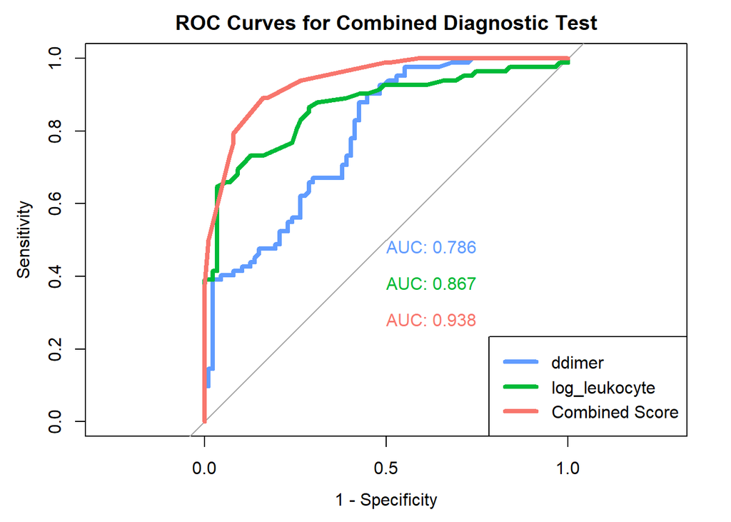

```
## k-Nearest Neighbors
##
## 169 samples
##   2 predictor
##   2 classes: 'not_needed', 'needed'
##
## Pre-processing: centered (2), scaled (2)
## Resampling: Cross-Validated (10 fold, repeated 5 times)
## Summary of sample sizes: 153, 152, 152, 152, 152, 152, ...
## Resampling results across tuning parameters:
##
##   k  Accuracy   Kappa
##   5  0.8296732  0.6579079
##   7  0.8370997  0.6724499
##   9  0.8372386  0.6729296
##
## Accuracy was used to select the optimal model using the largest value.
## The final value used for the model was k = 9.
##
##
## Area Under the Curves of markers and combined score:
##                     AUC     SE.AUC LowerLimit UpperLimit        z       p.value
## ddimer        0.7858845 0.03416018  0.7189318  0.8528372  8.36894  5.813887e-17
## log_leukocyte 0.8668349 0.02882818  0.8103327  0.9233371 12.72487  4.301880e-37
## Combined      0.9376927 0.01671680  0.9049284  0.9704571 26.18281 4.171133e-151
##
## Area Under the Curve comparison of markers and combined score:
##   Marker1 (A)   Marker2 (B)   AUC (A)   AUC (B)      |A-B|   SE(|A-B|)
## 1    Combined        ddimer 0.9376927 0.7858845 0.15180824  0.03131740
## 2    Combined log_leukocyte 0.9376927 0.8668349 0.07085786  0.02060721
## 3      ddimer log_leukocyte 0.7858845 0.8668349 0.08095038 -0.03971128
##           z      p-value
## 1  4.847408 1.250848e-06
## 2  3.438499 5.849497e-04
## 3 -2.038473 4.150264e-02
##
## Confusion matrix:
##           Outcome +    Outcome -      Total
## Test +           73           14         87
## Test -            9           73         82
## Total            82           87        169
##
## Point estimates and 95% CIs:
## --------------------------------------------------------------
## Apparent prevalence *                  0.51 (0.44, 0.59)
## True prevalence *                      0.49 (0.41, 0.56)
## Sensitivity *                          0.89 (0.80, 0.95)
## Specificity *                          0.84 (0.74, 0.91)
## Positive predictive value *            0.84 (0.74, 0.91)
## Negative predictive value *            0.89 (0.80, 0.95)
## Positive likelihood ratio              5.53 (3.40, 8.99)
## Negative likelihood ratio              0.13 (0.07, 0.24)
## False T+ proportion for true D- *      0.16 (0.09, 0.26)
## False T- proportion for true D+ *      0.11 (0.05, 0.20)
## False T+ proportion for T+ *           0.16 (0.09, 0.26)
## False T- proportion for T- *           0.11 (0.05, 0.20)
## Correctly classified proportion *      0.86 (0.80, 0.91)
## --------------------------------------------------------------
## * Exact CIs
```

```r
 #mathComb fonksiyonu
 math_result <- mathComb(markers = markers,
                         status = status,
                         event = "needed",
                         method = "distance",
                         distance = "euclidean",
                         direction = "<",
                         cutoff.method = "youden")
```

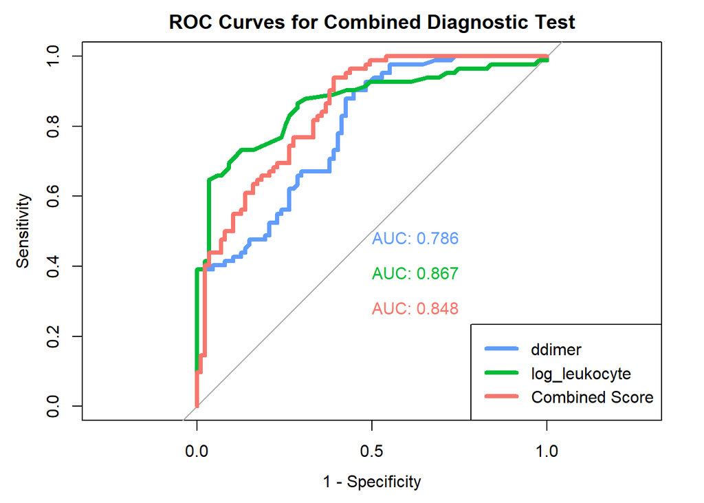

```
## Method: distance
## Distance: euclidean
## Samples: 169
## Markers: 2
## Events: not_needed, needed
## Standardization: none
## Transform: none
##
##  Kappa       Accuracy
##  0.5427045   0.7692308
##
## Area Under the Curves of markers and combined score:
##                     AUC     SE.AUC LowerLimit UpperLimit        z      p.value
## ddimer        0.7858845 0.03416018  0.7189318  0.8528372  8.36894 5.813887e-17
## log_leukocyte 0.8668349 0.02882818  0.8103327  0.9233371 12.72487 4.301880e-37
## Combined      0.8476311 0.02868437  0.7914107  0.9038514 12.11918 8.359065e-34
##
## Area Under the Curve comparison of markers and combined score:
##   Marker1 (A)   Marker2 (B)   AUC (A)   AUC (B)      |A-B|   SE(|A-B|)
## 1    Combined        ddimer 0.8476311 0.7858845 0.06174657  0.01323042
## 2    Combined log_leukocyte 0.8476311 0.8668349 0.01920381 -0.03182177
## 3      ddimer log_leukocyte 0.7858845 0.8668349 0.08095038 -0.03971128
##            z      p-value
## 1  4.6670140 3.056086e-06
## 2 -0.6034803 5.461892e-01
## 3 -2.0384732 4.150264e-02
##
## Confusion matrix:
##           Outcome +    Outcome -      Total
## Test +           77           34        111
## Test -            5           53         58
## Total            82           87        169
##
## Point estimates and 95% CIs:
## --------------------------------------------------------------
## Apparent prevalence *                  0.66 (0.58, 0.73)
## True prevalence *                      0.49 (0.41, 0.56)
## Sensitivity *                          0.94 (0.86, 0.98)
## Specificity *                          0.61 (0.50, 0.71)
## Positive predictive value *            0.69 (0.60, 0.78)
## Negative predictive value *            0.91 (0.81, 0.97)
## Positive likelihood ratio              2.40 (1.84, 3.14)
## Negative likelihood ratio              0.10 (0.04, 0.24)
## False T+ proportion for true D- *      0.39 (0.29, 0.50)
## False T- proportion for true D+ *      0.06 (0.02, 0.14)
## False T+ proportion for T+ *           0.31 (0.22, 0.40)
## False T- proportion for T- *           0.09 (0.03, 0.19)
## Correctly classified proportion *      0.77 (0.70, 0.83)
## --------------------------------------------------------------
## * Exact CIs
```

[figure not shown]

Test senaryolarının sınıf etiketleri, eğitilen modelin model özelliklerine göre tahmin edilir, örn. doğrusal kombinasyon metotlarından **scoring** yöntemini kullanarak bir model eğitiyorsak test setinin etiketleri eğitim setinden sakladığımız parametler doğrultusunda elde edilir. Ancak burada önemli bir nokta, test setinin eğitim seti ile aynı aşamaları geçmiş olması gerektiğidir.

```r
#Hadi yeni tahmin yapalım!
predComb(lin_result, testData)
```

```
##     comb.score     labels
## 83   6.5362799     needed
## 84   2.7004641 not_needed
## 85   5.1000583     needed
## 86   6.6062764     needed
## 87   6.7737255     needed
## 88   2.8883516 not_needed
## 89   2.9717405 not_needed
## 90   3.8378748 not_needed
## 91   3.1464499 not_needed
## 92   5.2652960     needed
## 93   0.7047720 not_needed
## 94   3.1253854 not_needed
## 95   4.1240099     needed
## 96   3.1412486 not_needed
```

[output cut: 42 more lines]

Yazılımın geliştirme süreci Github ortamında gerçekleştirilmiş 18 adet pull requests oluşturulmuştur. Paketin oluşturulma aşaması devtools kütüphanesi ile gerçekleştirilmiştir. Yazılım testleri ise R programlama dilinin testhat kütüphanesi kullanılarak 219 adet birim test yapılmıştır.

# References

[1] Zararsiz G, Akyildiz HY, Goksuluk D, Korkmaz S, Ozturk A (2016). Statistical learning approaches in diagnosing patients with nontraumatic acute abdomen. Turk J Elec Eng & Comp Sci, 24:3685-97.

[2] Su, J. Q., & Liu, J. S. (1993). Linear combinations of multiple diagnostic markers. Journal of the American Statistical Association, 88(424), 1350-1355.

[3]Liu, C., Liu, A., & Halabi, S. (2011). A min–max combination of biomarkers to improve diagnostic accuracy. Statistics in medicine, 30(16), 2005-2014.

[4] Pepe, M. S., & Thompson, M. L. (2000). Combining diagnostic test results to increase accuracy. Biostatistics, 1(2), 123-140.

[5] Pepe, M. S., Cai, T., & Longton, G. (2006). Combining predictors for classification using the area under the receiver operating characteristic curve. Biometrics, 62(1), 221-229.

[6] Sameera, G., Vardhan, R. V., & Sarma, K. V. S. (2016). Binary classification using multivariate receiver operating characteristic curve for continuous data. Journal of biopharmaceutical statistics, 26(3), 421-431.

[7] Todor, N., Todor, I., & Săplăcan, G. (2014). Tools to identify linear combination of prognostic factors which maximizes area under receiver operator curve. Journal of clinical bioinformatics, 4(1), 1-7.

[8] Jerome Friedman, Trevor Hastie, Robert Tibshirani (2010). Regularization Paths for Generalized Linear Models via Coordinate Descent. Journal of Statistical Software, 33(1), 1-22. URL https://www.jstatsoft.org/v33/i01/.

[9] R Core Team (2021). R: A language and environment for statistical computing. R Foundation for Statistical Computing, Vienna, Austria. URL https://www.R-project.org/.

[10] Trevor Hastie (2020). gam: Generalized Additive Models. R package version 1.20. https://CRAN.R-project.org/package=gam

[11] Max Kuhn (2021). caret: Classification and Regression Training. R package version 6.0-89. https://CRAN.R-project.org/package=caret